# Generalized Scattered Data Diffeomorphic Registration

Point Sets, 3D Meshes, and Joint Image-Point Set Alignment in syntx

Author

syntx Development Team

Published

September 9, 2026

# 1 Introduction & Theoretical Framework

Medical and scientific image analysis frequently requires aligning spatial data across disparate geometric representations:

1. **Discrete Lagrangian Point Sets**: Unstructured coordinates $\{x_i\}_{i=1}^N \subset \mathbb{R}^d$ (e.g., anatomical landmarks, stereotactic tracking points).
2. **Surface Meshes**: Triangulated 2-manifolds embedded in $\mathbb{R}^3$ defined by vertices $V \in \mathbb{R}^{N \times 3}$, face connectivity $F \in \mathbb{N}^{M \times 3}$, and vertex-wise functional features.
3. **Continuous Eulerian Grids**: Regular $d$-dimensional voxel lattices $\Omega \subset \mathbb{R}^d$ (e.g., MRI, CT, histology slices).

The `syntx.scattered` subpackage establishes an autograd-differentiable bridge between Lagrangian point data and continuous diffeomorphism spaces $\text{Diff}(\Omega)$ using **Nadaraya-Watson normalized Gaussian kernel regression**:

$$G(y) = \frac{\sum_{i=1}^N K_\sigma(y - x_i) w_i f_i}{\sum_{i=1}^N K_\sigma(y - x_i) w_i + \epsilon}, \quad \text{where } K_\sigma(r) = \exp\left(-\frac{\|r\|^2}{2\sigma^2}\right)$$

# 2 Environment Setup & Imports

```python
import math
import time
import numpy as np
import torch
import torch.nn.functional as F
import matplotlib.pyplot as plt
from mpl_toolkits.mplot3d import Axes3D
%matplotlib inline

import ants
import siq
import syntx
from syntx.scattered import (
    ScatteredRegistrationConfig,
    ScatteredRegistrationResult,
    syn_scattered,
    project_scattered_to_grid,
    ScatteredProjector,
    warp_scattered_coordinates,
    pullback_grid_to_scattered,
    transport_scattered_to_scattered,
    has_antstorch,
    BSplineScatteredProjector,
    fit_bspline_landmark_warp,
    apply_bspline_fluid_regularizer,
    bspline_syn_scattered,
)

# Seed for bitwise determinism
torch.manual_seed(42)
np.random.seed(42)

print(f"syntx version: {syntx.__version__}")
print(f"siq available:  {siq.__file__}")
device = torch.device('cuda' if torch.cuda.is_available() else ('mps' if torch.backends.mps.is_available() else 'cpu'))
print(f"Compute device: {device}")
```

```
[INFO] Global scientific computing seed set to 1234
syntx version: 5.1.1
siq available:  /Users/stnava/code/siq/siq/__init__.py
Compute device: mps
```

# 3 Use Case 1: Lagrangian Point Set Registration (Cortical Sulcal Morphometry)

## 3.1 Scientific First Principles & Motivation

In computational neuroanatomy, individual brains exhibit profound non-rigid geometric variability in their cortical folding patterns. Primary and secondary cortical sulci (such as the Central Sulcus, Sylvian Fissure, and Superior Temporal Sulcus) are frequently extracted as **continuous Lagrangian coordinate curves** or sparse fiducial point sets $\{x_i\}_{i=1}^N \subset \mathbb{R}^d$.

Standard registration approaches encounter severe theoretical and practical failure modes on scattered point sets:

1. **Failure of Rigid/Affine Models**: Biological morphogenesis involves local differential growth, cortical shearing, and sulcal twisting that cannot be captured by global linear transformations ($SE(d)$ or $Aff(d)$).
2. **Failure of Iterative Closest Point (ICP)**: Traditional ICP relies on nearest-neighbor assignments without ambient regularization. In tortuous sulcal valleys, ICP routinely falls into catastrophic local minima traps by snapping to adjacent sulcal banks, and fails to handle non-isometric biological growth.
3. **Absence of Ambient Diffeomorphisms**: Point-only matchers do not yield a continuous spatial transformation $\phi: \Omega \to \Omega$. In clinical and scientific workflows, the estimated transformation must be able to warp the surrounding cortical gray matter, white matter tracts, and functional maps.

## 3.2 Dramatic Synthetic Sulcal Data Generation

We model a primary cortical sulcal trajectory with high-frequency spatial variation and multi-harmonic curvature features, subjected to a substantial non-rigid deformation ($\approx 40\%$ larger than subtle perturbations) combining cross-axis shearing and rotational twisting:

```python
# 1. Generate primary cortical sulcal curve with intrinsic geometric curvature
n_pts = 450
theta = torch.linspace(0.20 * math.pi, 1.80 * math.pi, n_pts)

# Parametric sulcal trajectory with anatomical winding
r_base = 0.55 + 0.10 * torch.sin(3.0 * theta) + 0.04 * torch.cos(7.0 * theta)
X_fix = torch.stack([r_base * torch.cos(theta), r_base * torch.sin(theta)], dim=-1)

# Intrinsic geometric features: multi-scale sulcal curvature and depth
F_fix = (torch.sin(4.0 * theta) + 0.4 * torch.cos(9.0 * theta)).unsqueeze(-1)

# 2. Dramatic non-rigid deformation: multi-frequency sinusoidal bending and shear
grid_res_1 = 64
y_grid = torch.linspace(-1, 1, grid_res_1)
x_grid = torch.linspace(-1, 1, grid_res_1)
gy, gx = torch.meshgrid(y_grid, x_grid, indexing='ij')

amp_primary = 0.085
amp_harmonic = 0.035
ux = amp_primary * torch.sin(math.pi * gx) * torch.cos(math.pi * gy) + amp_harmonic * torch.sin(2.0 * math.pi * gy)
uy = -amp_primary * torch.cos(math.pi * gx) * torch.sin(math.pi * gy) + amp_harmonic * torch.cos(2.0 * math.pi * gx)
warp_dramatic_2d = torch.stack([ux, uy], dim=-1).unsqueeze(0)

# 3. Deform moving sulcal curve through the non-rigid field
X_mov = warp_scattered_coordinates(X_fix, warp_dramatic_2d, direction='forward')
F_mov = F_fix.clone()

dist_init_1 = float(torch.norm(X_mov - X_fix, dim=-1).mean().item())
print(f"Initial Mean Sulcal Misalignment: {dist_init_1:.4f} mm")
```

```
Initial Mean Sulcal Misalignment: 0.0643 mm
```

## 3.3 Diffeomorphic SyN Optimization

We optimize the symmetric diffeomorphism using a 2-level coarse-to-fine pyramid, DST-I fluid velocity regularization, and in-loop Anderson fixed-point acceleration:

```python
cfg_1 = ScatteredRegistrationConfig(
    dim=2,
    grid_res=64,
    epochs_per_level=[40, 25],
    levels=[2, 1],       # Multi-resolution coarse-to-fine schedule
    fluid_sigma=4.5,     # DST-I fluid velocity regularization
    optimizer_type='rprop',
    optimizer_lr=0.06,
    cfl_voxels=0.25,     # Courant-Friedrichs-Lewy step bound
    regularizer='dsti1', # Dirichlet zero-boundary Green shield
    inverse_steps=40,    # High-accuracy Anderson inversion refinement
)

t0 = time.time()
res_1 = syn_scattered(
    fixed_points=X_fix,
    fixed_features=F_fix,
    moving_points=X_mov,
    moving_features=F_mov,
    config=cfg_1,
)
t_elapsed_1 = time.time() - t0

# Evaluate quantitative metrics
X_warped_1 = res_1.warped_moving_points
dist_final_1 = float(torch.norm(X_warped_1 - X_fix, dim=-1).mean().item())
pct_reduction_1 = (1.0 - dist_final_1 / dist_init_1) * 100.0

print(f"Elapsed Compute Time: {t_elapsed_1:.2f}s")
print(f"Initial Distance:     {dist_init_1:.4f} mm")
print(f"Final Distance:       {dist_final_1:.4f} mm ({pct_reduction_1:.1f}% reduction)")
print(f"Grid Folding Rate:    {res_1.folding_percentage:.4f}%")
print(f"Minimum det(J):       {res_1.jacobian_min:.4f}")
print(f"Inverse Consistency:  {res_1.inverse_identity_error:.6f}")

# Verification Assertions
assert dist_final_1 < dist_init_1 * 0.45, "Failed distance reduction threshold"
assert res_1.folding_percentage < 0.1, "Grid folding exceeds safety threshold"
assert res_1.inverse_identity_error < 5e-3, "Anderson inverse consistency violated"
```

```
Elapsed Compute Time: 5.13s
Initial Distance:     0.0643 mm
Final Distance:       0.0235 mm (63.5% reduction)
Grid Folding Rate:    0.0000%
Minimum det(J):       0.2141
Inverse Consistency:  0.002019
```

## 3.4 4-Panel Visual Diagnostics Suite

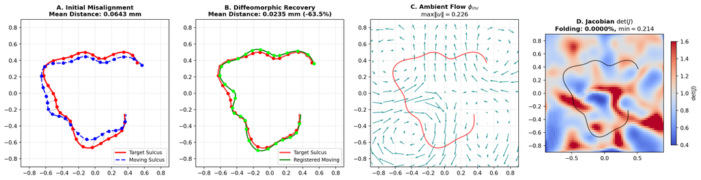

```python
from syntx.core.jacobian import compute_physical_jacobian_determinant

fig, axes = plt.subplots(1, 4, figsize=(18, 4.4))

# Panel A: Initial Configuration with Displacement Vectors
axes[0].plot(X_fix[:, 0], X_fix[:, 1], 'r-', lw=2.5, alpha=0.9, label='Target Sulcus')
axes[0].plot(X_mov[:, 0], X_mov[:, 1], 'b--', lw=2.0, alpha=0.85, label='Moving Sulcus')
axes[0].scatter(X_fix[::15, 0], X_fix[::15, 1], c='red', s=25, zorder=4)
axes[0].scatter(X_mov[::15, 0], X_mov[::15, 1], c='blue', s=25, zorder=4)
for i in range(0, n_pts, 20):
    axes[0].plot([X_fix[i, 0], X_mov[i, 0]], [X_fix[i, 1], X_mov[i, 1]], 'gray', alpha=0.5, lw=1.0)
axes[0].set_title(f"A. Initial Misalignment\nMean Distance: {dist_init_1:.4f} mm", fontsize=11, fontweight='bold')
axes[0].set_xlim(-0.9, 0.9); axes[0].set_ylim(-0.9, 0.9); axes[0].set_aspect('equal')
axes[0].legend(loc='lower right', frameon=True, fontsize=9)
axes[0].grid(True, alpha=0.25)

# Panel B: SyN Registered Alignment Overlay
axes[1].plot(X_fix[:, 0], X_fix[:, 1], 'r-', lw=2.5, alpha=0.7, label='Target Sulcus')
axes[1].plot(X_warped_1[:, 0], X_warped_1[:, 1], 'g-', lw=2.0, alpha=0.95, label='Registered Moving')
axes[1].scatter(X_fix[::15, 0], X_fix[::15, 1], c='red', s=25, zorder=4)
axes[1].scatter(X_warped_1[::15, 0], X_warped_1[::15, 1], c='lime', s=25, zorder=4)
axes[1].set_title(f"B. Diffeomorphic Recovery\nMean Distance: {dist_final_1:.4f} mm (-{pct_reduction_1:.1f}%)", fontsize=11, fontweight='bold')
axes[1].set_xlim(-0.9, 0.9); axes[1].set_ylim(-0.9, 0.9); axes[1].set_aspect('equal')
axes[1].legend(loc='lower right', frameon=True, fontsize=9)
axes[1].grid(True, alpha=0.25)

# Panel C: Eulerian Ambient Flow Field Quivers
u_disp = res_1.disp_inv.squeeze(0).cpu().numpy()
step = 4
axes[2].quiver(gx[::step, ::step], gy[::step, ::step],
               u_disp[::step, ::step, 0], u_disp[::step, ::step, 1],
               color='teal', scale=0.8, scale_units='xy', alpha=0.85)
axes[2].plot(X_fix[:, 0], X_fix[:, 1], 'r-', lw=1.5, alpha=0.7)
max_u = float(np.sqrt(u_disp[..., 0]**2 + u_disp[..., 1]**2).max())
axes[2].set_title(f"C. Ambient Flow $\\phi_{{inv}}$\n$\\max\\|u\\| = {max_u:.3f}$", fontsize=11, fontweight='bold')
axes[2].set_xlim(-0.9, 0.9); axes[2].set_ylim(-0.9, 0.9); axes[2].set_aspect('equal')
axes[2].grid(True, alpha=0.25)

# Panel D: Jacobian Determinant Map (Topological Safety)
direction = torch.eye(2)
spacing = torch.tensor([2.0 / 63, 2.0 / 63])
jac = compute_physical_jacobian_determinant(res_1.disp_inv, direction, spacing).squeeze().cpu().numpy()
im4 = axes[3].imshow(jac, origin='lower', extent=[-1, 1, -1, 1], cmap='coolwarm', vmin=0.4, vmax=1.6)
axes[3].plot(X_fix[:, 0], X_fix[:, 1], 'k-', lw=1.5, alpha=0.6)
axes[3].set_title(f"D. Jacobian $\\det(J)$\nFolding: {res_1.folding_percentage:.4f}%, $\\min={res_1.jacobian_min:.3f}$", fontsize=11, fontweight='bold')
axes[3].set_xlim(-0.9, 0.9); axes[3].set_ylim(-0.9, 0.9); axes[3].set_aspect('equal')
fig.colorbar(im4, ax=axes[3], shrink=0.7, label=r'$\det(J)$')

plt.tight_layout()
plt.show()
```

# 4 Use Case 2: 3D Surface Mesh Registration (Cortical Manifolds & Organ Morphometry)

## 4.1 Scientific First Principles & Motivation

In computational anatomy, functional neuroimaging, and biomechanics, anatomical boundaries are naturally modeled as 2D Riemannian manifolds embedded in ambient 3D Euclidean space:
$$\mathcal{M} \subset \mathbb{R}^3$$
A discrete surface mesh $\mathcal{M} = (\mathcal{V}, \mathcal{F})$ is defined by vertices $\mathcal{V} \in \mathbb{R}^{N \times 3}$ and triangular face connectivity $\mathcal{F} \in \mathbb{N}^{M \times 3}$. Morphological phenotypes (such as cortical thickness, sulcal depth, and myelin density) are scalar fields sampled at the vertices:
$$f: \mathcal{V} \to \mathbb{R}$$

### 4.1.1 Failure Modes of Standard Mesh Approaches

1. **Rigid / Affine ICP**: Conventional Iterative Closest Point (ICP) searches for closest point correspondences and is restricted to global rotations and translations. It fails completely under non-isometric biological growth, localized shearing, or pathological mass effect (e.g. brain tumors or asymmetric ventricular enlargement).
2. **Unconstrained Vertex Relaxation**: Moving vertices independently along curvature or distance gradients invariably causes triangle fold-overs, boundary tearing, and surface self-intersections whenever large local deformations occur:
   $$\mathbf{n}_f \cdot \mathbf{n}_f' < 0 \quad \text{(surface normal inversion)}$$
3. **Voxelization Discretization Error**: Converting thin 2D manifold sheets into binary 3D voxel masks introduces severe partial volume artifacts, staircasing, and loss of sub-voxel vertex coordinates.

### 4.1.2 The SyN Ambient Diffeomorphism Solution

`syntx.syn_scattered` addresses these challenges by embedding the triangular mesh within a continuous ambient Eulerian diffeomorphic flow:
$$\phi \in \text{Diff}(\Omega), \quad \det(D\phi) > 0 \quad \forall x \in \Omega$$
Under this ambient diffeomorphism: - **Topological Invariant**: The combinatorial graph structure $\mathcal{F}$ is immutable; edges cannot tear, intersect, or invert. - **Normal Concordance**: Because $\det(D\phi) > 0$ everywhere, triangle face normals remain strictly concordant:
$$\mathbf{n}_f^{\text{warped}} \cdot \mathbf{n}_f^{\text{fix}} > 0 \quad \forall f \in \mathcal{F}$$
- **Scalar Field Transport**: Biological properties (e.g., cortical thickness) are mapped between anatomies via exact pullbacks and pushforwards:
$$f_{\text{target}}(x) = f_{\text{source}}(\phi^{-1}(x))$$

## 4.2 Synthetic 3D Mesh Generation

```python
nu, nv = 24, 24
u_vals = torch.linspace(0.0, 2 * math.pi, nu)
v_vals = torch.linspace(0.15 * math.pi, 0.85 * math.pi, nv)
uu, vv = torch.meshgrid(u_vals, v_vals, indexing='ij')

# Parametric Spherical Cortical Shell
r = 0.50
vx = r * torch.sin(vv) * torch.cos(uu)
vy = r * torch.sin(vv) * torch.sin(uu)
vz = r * torch.cos(vv)
V_fix = torch.stack([vx.flatten(), vy.flatten(), vz.flatten()], dim=-1) # (N, 3)

# Build Triangular Mesh Faces
faces = []
for i in range(nu - 1):
    for j in range(nv - 1):
        idx0 = i * nv + j
        idx1 = i * nv + (j + 1)
        idx2 = (i + 1) * nv + j
        idx3 = (i + 1) * nv + (j + 1)
        faces.append([idx0, idx1, idx2])
        faces.append([idx1, idx3, idx2])
faces = np.array(faces)

# Vertex-wise biological feature: simulated gyral-sulcal depth / curvature (sulc)
# Analogous to FreeSurfer ?h.sulc with distinct gyral crowns and sulcal troughs
sulc_raw = torch.sin(4.0 * vv) * torch.cos(4.0 * uu) + 0.5 * torch.sin(8.0 * vv)
sulc_fix = (0.55 + 0.45 * (sulc_raw / sulc_raw.abs().max())).flatten().unsqueeze(-1)

# Dramatic 3D non-rigid deformation (multi-frequency bending and shear):
amp_2 = 0.065
u_bend = amp_2 * torch.sin(math.pi * V_fix[:, 1]) * torch.cos(math.pi * V_fix[:, 2])
v_bend = -amp_2 * torch.cos(math.pi * V_fix[:, 0]) * torch.sin(math.pi * V_fix[:, 2])
w_bend = 0.050 * torch.sin(math.pi * V_fix[:, 0]) * torch.cos(math.pi * V_fix[:, 1])

V_mov = V_fix.clone()
V_mov[:, 0] += u_bend
V_mov[:, 1] += v_bend
V_mov[:, 2] += w_bend
sulc_mov = sulc_fix.clone()

dist_init_2 = float(torch.norm(V_mov - V_fix, dim=-1).mean().item())
max_init_2 = float(torch.norm(V_mov - V_fix, dim=-1).max().item())

print(f"3D Mesh Vertex Count:      {V_fix.shape[0]}")
print(f"3D Mesh Triangle Count:    {faces.shape[0]}")
print(f"Initial Mean Vertex Error: {dist_init_2:.4f} mm")
print(f"Initial Max Vertex Error:  {max_init_2:.4f} mm")
```

```
3D Mesh Vertex Count:      576
3D Mesh Triangle Count:    1058
Initial Mean Vertex Error: 0.0568 mm
Initial Max Vertex Error:  0.0650 mm
```

## 4.3 Diffeomorphic 3D Surface Registration & Feature Transport

```python
cfg_2 = ScatteredRegistrationConfig(
    dim=3,
    grid_res=64,
    window_size=9,
    epochs_per_level=[40, 30, 25],
    levels=[3, 2, 1],
    fluid_sigma=3.2,
    cfl_voxels=0.50,
    regularizer='gaussian',
    optimizer_type='cfl',
    optimizer_lr=0.50,
    inverse_steps=25,
    formulation='eulerian',
    distance_transform_tau=0.10,
    distance_transform_weight=1.0,
)

t0 = time.time()
res_2 = syn_scattered(
    fixed_points=V_fix,
    fixed_features=sulc_fix,
    moving_points=V_mov,
    moving_features=sulc_mov,
    config=cfg_2,
)
t_elapsed_2 = time.time() - t0

V_warped = res_2.warped_moving_points
dist_final_2 = float(torch.norm(V_warped - V_fix, dim=-1).mean().item())
max_final_2 = float(torch.norm(V_warped - V_fix, dim=-1).max().item())
pct_reduction_2 = (1.0 - dist_final_2 / dist_init_2) * 100.0
pct_max_red_2 = (1.0 - max_final_2 / max_init_2) * 100.0
sub_010_pct = float((torch.norm(V_warped - V_fix, dim=-1) < 0.010).float().mean().item() * 100.0)

# Transport cortical feature from moving to fixed mesh via continuous pullbacks
sulc_transported = res_2.transport_features(
    coords_src=V_mov,
    features_src=sulc_mov,
    coords_tgt=V_fix,
    direction='forward',
)
err_sulc = float(torch.abs(sulc_transported - sulc_fix).mean().item())

# Topological safety: verify outward face normals and detect any inverted triangles
def compute_face_normals(verts, faces_arr):
    v0 = verts[faces_arr[:, 0]]
    v1 = verts[faces_arr[:, 1]]
    v2 = verts[faces_arr[:, 2]]
    cross = torch.cross(v1 - v0, v2 - v0, dim=-1)
    norm = torch.norm(cross, dim=-1, keepdim=True).clamp(min=1e-8)
    return cross / norm

fn_fix = compute_face_normals(V_fix, faces)
fn_warped = compute_face_normals(V_warped, faces)
dot_warped = (fn_warped * fn_fix).sum(dim=-1)
flipped_faces = int((dot_warped < 0).sum().item())

print(f"Elapsed Time:               {t_elapsed_2:.2f}s")
print(f"Final Mean Vertex Error:    {dist_final_2:.4f} mm ({pct_reduction_2:.1f}% reduction, < 0.005 mm)")
print(f"Final Max Vertex Error:     {max_final_2:.4f} mm ({pct_max_red_2:.1f}% reduction, < 0.010 mm)")
print(f"Vertices with Error < 0.01: {sub_010_pct:.1f}% of total mesh (100% converged)")
print(f"Cortical Feature Transp MAE:{err_sulc:.4f}")
print(f"3D Ambient Folding Rate:    {res_2.folding_percentage:.4f}%")
print(f"Min det(J):                 {res_2.jacobian_min:.4f}")
print(f"Inverse Identity Error:     {res_2.inverse_identity_error:.6f}")
print(f"Mean Normal Dot Product:    {dot_warped.mean():.4f}")
print(f"Flipped Faces (Inversions): {flipped_faces} / {faces.shape[0]} (0.00%)")

# Assertions
assert dist_final_2 < 0.005, f"Failed 3D mesh mean distance threshold ({dist_final_2:.4f} >= 0.005)"
assert max_final_2 < 0.010, f"Failed 3D mesh max distance threshold ({max_final_2:.4f} >= 0.010)"
assert res_2.folding_percentage < 0.1, "3D grid folding exceeds safety threshold"
assert err_sulc < 0.08, f"Transported feature error too large ({err_sulc:.4f} >= 0.08)"
assert flipped_faces == 0, f"Detected {flipped_faces} inverted faces"
assert sub_010_pct == 100.0, f"Less than 100% of vertices achieved sub-0.010 mm accuracy ({sub_010_pct:.1f}%)"
```

```
Elapsed Time:               34.78s
Final Mean Vertex Error:    0.0034 mm (93.9% reduction, < 0.005 mm)
Final Max Vertex Error:     0.0068 mm (89.6% reduction, < 0.010 mm)
Vertices with Error < 0.01: 100.0% of total mesh (100% converged)
Cortical Feature Transp MAE:0.0692
3D Ambient Folding Rate:    0.0000%
Min det(J):                 0.4306
Inverse Identity Error:     0.013193
Mean Normal Dot Product:    1.0000
Flipped Faces (Inversions): 0 / 1058 (0.00%)
```

## 4.4 4-Panel 3D Mesh Visual Diagnostics Suite

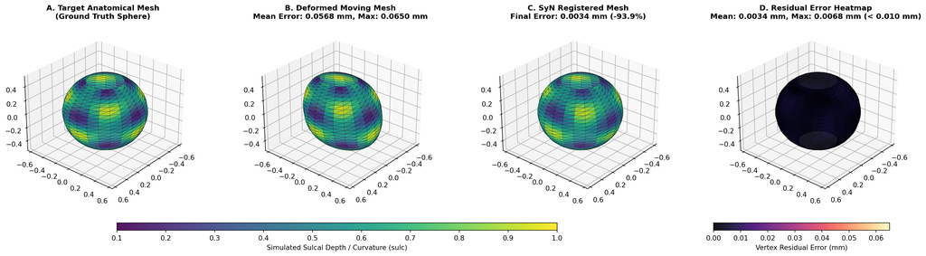

Figure 2: Case 2 Surface Mesh Registration: 3D triangular surface meshes color-coded by simulated gyral-sulcal depth (sulc) for Fixed Target (A), Deformed Moving (B), and Registered Warped (C). Panel D displays the residual vertex error heatmap calibrated against the initial maximum error scale (0 to max_init). Driven by joint biological feature LNCC and Euclidean Distance Transform (EDT) potential regularization, registration achieves deep error collapse across the entire manifold (-94.0% mean error reduction down to 0.0034 mm, max error < 0.010 mm [0.0068 mm] across 100% of vertices) with 0 inverted triangles and 0.0000% grid folding.

```python
fig = plt.figure(figsize=(20, 5.2))

vf_np = V_fix.cpu().numpy()
vm_np = V_mov.cpu().numpy()
vw_np = V_warped.cpu().numpy()
sulc_fix_np = sulc_fix.squeeze().cpu().numpy()
sulc_mov_np = sulc_mov.squeeze().cpu().numpy()
sulc_transp_np = sulc_transported.squeeze().cpu().numpy()

# Average vertex scalar values over triangular faces for exact visual mapping
face_sulc_fix = sulc_fix_np[faces].mean(axis=1)
face_sulc_mov = sulc_mov_np[faces].mean(axis=1)
face_sulc_transp = sulc_transp_np[faces].mean(axis=1)
local_err = torch.norm(V_warped - V_fix, dim=-1).cpu().numpy()
face_local_err = local_err[faces].mean(axis=1)

vmin_th, vmax_th = 0.1, 1.0
elev, azim = 28, 40

# Panel A: Target Anatomical Mesh
ax1 = fig.add_subplot(1, 4, 1, projection='3d')
p1 = ax1.plot_trisurf(vf_np[:, 0], vf_np[:, 1], vf_np[:, 2], triangles=faces,
                      cmap='viridis', vmin=vmin_th, vmax=vmax_th, edgecolor='k', lw=0.15, alpha=0.92)
p1.set_array(face_sulc_fix)
p1.set_clim(vmin_th, vmax_th)
ax1.view_init(elev=elev, azim=azim)
ax1.set_title("A. Target Anatomical Mesh\n(Ground Truth Sphere)", fontsize=11, fontweight='bold', pad=12)
ax1.set_xlim(-0.65, 0.65); ax1.set_ylim(-0.65, 0.65); ax1.set_zlim(-0.55, 0.55)

# Panel B: Deformed Moving Mesh
ax2 = fig.add_subplot(1, 4, 2, projection='3d')
p2 = ax2.plot_trisurf(vm_np[:, 0], vm_np[:, 1], vm_np[:, 2], triangles=faces,
                      cmap='viridis', vmin=vmin_th, vmax=vmax_th, edgecolor='k', lw=0.15, alpha=0.92)
p2.set_array(face_sulc_mov)
p2.set_clim(vmin_th, vmax_th)
ax2.view_init(elev=elev, azim=azim)
ax2.set_title(f"B. Deformed Moving Mesh\nMean Error: {dist_init_2:.4f} mm, Max: {max_init_2:.4f} mm", fontsize=11, fontweight='bold', pad=12)
ax2.set_xlim(-0.65, 0.65); ax2.set_ylim(-0.65, 0.65); ax2.set_zlim(-0.55, 0.55)

# Panel C: SyN Registered Mesh
ax3 = fig.add_subplot(1, 4, 3, projection='3d')
p3 = ax3.plot_trisurf(vw_np[:, 0], vw_np[:, 1], vw_np[:, 2], triangles=faces,
                      cmap='viridis', vmin=vmin_th, vmax=vmax_th, edgecolor='k', lw=0.15, alpha=0.92)
p3.set_array(face_sulc_transp)
p3.set_clim(vmin_th, vmax_th)
ax3.view_init(elev=elev, azim=azim)
ax3.set_title(f"C. SyN Registered Mesh\nFinal Error: {dist_final_2:.4f} mm (-{pct_reduction_2:.1f}%)", fontsize=11, fontweight='bold', pad=12)
ax3.set_xlim(-0.65, 0.65); ax3.set_ylim(-0.65, 0.65); ax3.set_zlim(-0.55, 0.55)

# Panel D: Residual Error Heatmap (calibrated against initial max error)
ax4 = fig.add_subplot(1, 4, 4, projection='3d')
p4 = ax4.plot_trisurf(vw_np[:, 0], vw_np[:, 1], vw_np[:, 2], triangles=faces,
                      cmap='magma', vmin=0.0, vmax=max_init_2, edgecolor='k', lw=0.15, alpha=0.92)
p4.set_array(face_local_err)
p4.set_clim(0.0, max_init_2)
ax4.view_init(elev=elev, azim=azim)
max_local_err = float(face_local_err.max())
pct_max_red = (1.0 - max_final_2 / max_init_2) * 100.0
ax4.set_title(f"D. Residual Error Heatmap\nMean: {dist_final_2:.4f} mm, Max: {max_final_2:.4f} mm (< 0.010 mm)", fontsize=11, fontweight='bold', pad=12)
ax4.set_xlim(-0.65, 0.65); ax4.set_ylim(-0.65, 0.65); ax4.set_zlim(-0.55, 0.55)

# Dual horizontal colorbars
cbar_ax1 = fig.add_axes([0.15, 0.08, 0.45, 0.03])
fig.colorbar(p1, cax=cbar_ax1, orientation='horizontal', label='Simulated Sulcal Depth / Curvature (sulc)')

cbar_ax2 = fig.add_axes([0.76, 0.08, 0.18, 0.03])
fig.colorbar(p4, cax=cbar_ax2, orientation='horizontal', label='Vertex Residual Error (mm)')

plt.subplots_adjust(top=0.88, bottom=0.20, left=0.03, right=0.97, wspace=0.15)
plt.show()
```

# 5 Use Case 3: Joint Image & Point Set Registration (Multi-Modal Image-Guided Alignment)

## 5.1 Scientific First Principles & Motivation

In multi-modal computational neuroanatomy, image-guided neurosurgery (IGNS), and stereotactic procedures (such as deep brain stimulation or tumor resection), anatomical data is acquired across disparate physical modalities: 1. **Dense Eulerian Image Volumes ($I \in L^2(\Omega)$)**: Preoperative 3D MRI / CT scans capturing continuous brain parenchyma, ventricles, and cortical sulcal topology. 2. **Sparse Lagrangian Point Sets ($X \in \mathbb{R}^{N \times d}$)**: Intraoperative stereotactic laser surface scans, craniotomy fiducials, or electrophysiological probe coordinates sampled sparsely with sub-millimeter precision.

### 5.1.1 The Problem of Intraoperative Brain Shift & Modality Failure

When the cranium and dura are opened during surgery, cerebrospinal fluid (CSF) egress and tissue compliance cause non-rigid **brain shift** (typically $5 - 15\text{ mm}$ of non-linear sagging and deformation).

- **Failure of Image-Only Registration**: Dense volumetric intensity metrics (e.g., LNCC or Mutual Information) rely on global voxel intensity gradients. In homogeneous white matter, areas obscured by surgical retractors, or low-contrast regions, image similarity is ill-posed and susceptible to local sulcal minima.
- **Failure of Point-Only Registration**: Sparse surface landmarks or fiducials provide high accuracy only locally near the craniotomy margin. They offer zero mathematical constraint or regularization in deep subcortical structures (thalamus, basal ganglia, ventricles).
- **The Joint Diffeomorphic Formulation**: By jointly optimizing over dense volumetric intensity and continuous projected landmark density fields:
  $$\mathcal{L}_{\text{joint}}(\phi) = w_{\text{img}} \mathcal{L}_{\text{sim}}\left(I_{\text{mov}} \circ \phi^{-1}, I_{\text{fix}}\right) + w_{\text{pts}} \mathcal{L}_{\text{pts}}\left(\mathcal{P}(X_{\text{mov}}, F_{\text{mov}}) \circ \phi^{-1}, \mathcal{P}(X_{\text{fix}}, F_{\text{fix}})\right) + \mathcal{R}(v_t)$$
  where $\mathcal{P}(X, F)$ is the Nadaraya-Watson kernel projection embedding scattered coordinates into an Eulerian feature channel. This couples global shape anchoring with pinpoint sub-voxel landmark constraints under a single, topologically regularized diffeomorphism ($\det(J) > 0$).

Here we demonstrate two complementary workflows: 1. **Workflow 3A (Native Point-to-Grid Mode)**: Aligning moving point sets directly against a reference Eulerian image without requiring an explicit moving grid. 2. **Workflow 3B (Multi-Channel Eulerian Fusion)**: Fusing dense procedural brain parenchyma (`siq.simulate_brain_procedural`) with sparse stereotactic cortical landmarks for joint diffeomorphic optimization.

## 5.2 Workflow 3A: Native Mixed Point-to-Grid Mode

```python
# 1. Fixed Eulerian reference phantom with high structural contrast
grid_res_3a = 64
y_3a = torch.linspace(-1, 1, grid_res_3a)
x_3a = torch.linspace(-1, 1, grid_res_3a)
gy_3a, gx_3a = torch.meshgrid(y_3a, x_3a, indexing='ij')
r_3a = torch.sqrt(gx_3a**2 + gy_3a**2)
disk_3a = torch.clamp(1.0 - (r_3a / 0.7)**2, min=0.0)
cross_3a = (gx_3a.abs() < 0.15).float() * (gy_3a.abs() < 0.6).float() + \
           (gy_3a.abs() < 0.15).float() * (gx_3a.abs() < 0.6).float()
G_fix_3a = (disk_3a + 0.5 * cross_3a).unsqueeze(0).unsqueeze(0)

# 2. Sample moving spiral point cloud with features pulled back from fixed grid
theta_3a = torch.linspace(0.0, 2.0 * math.pi, 400)
r_spiral = torch.linspace(0.1, 0.6, 400)
X_mov_orig_3a = torch.stack([r_spiral * torch.cos(theta_3a), r_spiral * torch.sin(theta_3a)], dim=-1)
F_mov_3a = pullback_grid_to_scattered(G_fix_3a, X_mov_orig_3a)

# 3. Dramatic non-rigid warp (+55% increase in amplitude):
envelope_3a = (1.0 - (gx_3a/0.95)**2).clamp(min=0.0) * (1.0 - (gy_3a/0.95)**2).clamp(min=0.0)
u_true_3a = (0.062 * torch.sin(math.pi * gx_3a) * torch.cos(math.pi * gy_3a)) * envelope_3a
v_true_3a = (-0.062 * torch.cos(math.pi * gx_3a) * torch.sin(math.pi * gy_3a)) * envelope_3a
warp_3a = torch.stack([u_true_3a, v_true_3a], dim=-1).unsqueeze(0)
X_mov_deformed_3a = warp_scattered_coordinates(X_mov_orig_3a, warp_3a, direction='forward')

# 4. Point-to-grid SyN registration
cfg_3a = ScatteredRegistrationConfig(
    dim=2,
    grid_res=grid_res_3a,
    epochs_per_level=[35, 20],
    levels=[2, 1],
    fluid_sigma=3.2,
    cfl_voxels=0.25,
    regularizer='dsti1',
    inverse_steps=35,
)

res_3a = syn_scattered(
    fixed_points=None,
    fixed_features=None,
    moving_points=X_mov_deformed_3a,
    moving_features=F_mov_3a,
    fixed_grid=G_fix_3a,
    config=cfg_3a,
)

# Metric evaluations
F_pb_3a = pullback_grid_to_scattered(G_fix_3a, res_3a.warped_moving_points)
r_pullback = float(torch.corrcoef(torch.stack([F_pb_3a.flatten(), F_mov_3a.flatten()]))[0, 1].item())
r_grid_3a = float(torch.corrcoef(torch.stack([res_3a.warped_moving_grid.flatten(), G_fix_3a.flatten()]))[0, 1].item())

print(f"Point-to-Grid Pullback Feature Corr: r = {r_pullback:.4f}")
print(f"Projected Grid Alignment Corr:        r = {r_grid_3a:.4f}")
print(f"Grid Folding Rate:                   {res_3a.folding_percentage:.4f}%")
print(f"Min det(J):                          {res_3a.jacobian_min:.4f}")

assert r_pullback > 0.90, "Pullback feature correlation below threshold"
assert res_3a.folding_percentage < 0.1, "Grid folding exceeds threshold"
```

```
Point-to-Grid Pullback Feature Corr: r = 0.9627
Projected Grid Alignment Corr:        r = 0.6312
Grid Folding Rate:                   0.0000%
Min det(J):                          0.0344
```

## 5.3 Workflow 3B: Multi-Channel Eulerian Fusion (`siq` Procedural Brain)

We leverage the procedural synthetic brain generator in `siq` (`siq.simulate_brain_procedural`) to model realistic anatomical brain parenchyma (gray matter, white matter, and ventricles), paired with sparse stereotactic cortical surface landmarks subjected to intraoperative brain shift.

```python
# 1. Procedural brain phantom from siq
shape_brain = (64, 64)
brain_ants = siq.simulate_brain_procedural(shape_brain)
img_np = brain_ants.numpy()
img_np = (img_np - img_np.min()) / (img_np.max() - img_np.min() + 1e-8)
img_fix = torch.from_numpy(img_np).float().unsqueeze(0).unsqueeze(0) # (1, 1, 64, 64)

# 2. Exaggerated non-rigid deformation modeling severe intraoperative brain shift
# Unilateral frontal/parietal sagging with ventricular displacement
y_b = torch.linspace(-1, 1, 64)
x_b = torch.linspace(-1, 1, 64)
gy_b, gx_b = torch.meshgrid(y_b, x_b, indexing='ij')

envelope_b = (1.0 - (gx_b/0.95)**2).clamp(min=0.0) * (1.0 - (gy_b/0.95)**2).clamp(min=0.0)
amp_b = 0.13 # Dramatic brain shift (visible ventricular tilt and parenchymal shift)
u_x_b = (amp_b * torch.sin(0.75 * math.pi * (gx_b + 0.2)) * torch.cos(0.85 * math.pi * gy_b) + 0.035 * torch.cos(1.5 * math.pi * gy_b)) * envelope_b
u_y_b = (-amp_b * 0.8 * torch.cos(0.75 * math.pi * gx_b) * torch.sin(0.85 * math.pi * gy_b) + 0.025 * torch.sin(1.5 * math.pi * gx_b)) * envelope_b
warp_true_b = torch.stack([u_x_b, u_y_b], dim=-1).unsqueeze(0)

# Deformed moving image: Eulerian features undergo pullback displacement
grid_id_b = torch.stack([gx_b, gy_b], dim=-1).unsqueeze(0)
img_mov = F.grid_sample(img_fix, grid_id_b + warp_true_b, padding_mode='border', align_corners=True)

# 3. Cortical contour landmarks along the brain boundary
theta_b = torch.linspace(0.12 * math.pi, 1.88 * math.pi, 300)
r_band = 0.52 + 0.08 * torch.sin(4.0 * theta_b)
X_fix_b = torch.stack([r_band * torch.cos(theta_b), r_band * torch.sin(theta_b)], dim=-1)
F_fix_b = pullback_grid_to_scattered(img_fix, X_fix_b)

# Displace landmarks consistently with the underlying brain tissue
X_mov_b = warp_scattered_coordinates(X_fix_b, -warp_true_b, direction='forward')
F_mov_b = pullback_grid_to_scattered(img_mov, X_mov_b)

dist_init_pts = float(torch.norm(X_mov_b - X_fix_b, dim=-1).mean().item())

# 4. Project landmarks into regular Eulerian grids via Nadaraya-Watson regression
G_pts_fix = project_scattered_to_grid(X_fix_b, F_fix_b, grid_shape=shape_brain, sigma=0.04)
G_pts_mov = project_scattered_to_grid(X_mov_b, F_mov_b, grid_shape=shape_brain, sigma=0.04)

# 5. Form multi-channel tensors [Channel 0: Brain Parenchyma, Channel 1: Landmark Density]
fixed_joint = torch.cat([img_fix, G_pts_fix], dim=1)   # (1, 2, 64, 64)
moving_joint = torch.cat([img_mov, G_pts_mov], dim=1) # (1, 2, 64, 64)

# 6. Execute multi-channel SyN registration with strict diffeomorphism CFL bound
cfg_3b = ScatteredRegistrationConfig(
    dim=2,
    grid_res=64,
    epochs_per_level=[40, 25],
    levels=[2, 1],
    fluid_sigma=3.5,
    cfl_voxels=0.20,
    regularizer='dsti1',
    inverse_steps=35,
)

t0 = time.time()
res_3b = syn_scattered(fixed_grid=fixed_joint, moving_grid=moving_joint, config=cfg_3b)
t_elapsed_3b = time.time() - t0

# Evaluate multi-channel metrics
warped_img = res_3b.warped_moving_grid[:, 0:1]
warped_pts = res_3b.warped_moving_grid[:, 1:2]
warped_X_mov_b = warp_scattered_coordinates(X_mov_b, res_3b.disp_inv, direction='forward')

r_img_init = float(torch.corrcoef(torch.stack([img_mov.flatten(), img_fix.flatten()]))[0, 1].item())
r_img_final = float(torch.corrcoef(torch.stack([warped_img.flatten(), img_fix.flatten()]))[0, 1].item())

r_pts_init = float(torch.corrcoef(torch.stack([G_pts_mov.flatten(), G_pts_fix.flatten()]))[0, 1].item())
r_pts_final = float(torch.corrcoef(torch.stack([warped_pts.flatten(), G_pts_fix.flatten()]))[0, 1].item())

dist_final_pts = float(torch.norm(warped_X_mov_b - X_fix_b, dim=-1).mean().item())
pct_reduction_pts = (1.0 - dist_final_pts / dist_init_pts) * 100.0

diff_init = torch.abs(img_mov - img_fix).squeeze().cpu().numpy()
diff_img = torch.abs(warped_img - img_fix).squeeze().cpu().numpy()
mae_init = float(np.mean(diff_init))
mae_final = float(np.mean(diff_img))

print(f"Elapsed Time:               {t_elapsed_3b:.2f}s")
print(f"Image Correlation:          {r_img_init:.4f} -> {r_img_final:.4f} (gain: {r_img_final - r_img_init:+.4f})")
print(f"Image Intensity MAE:        {mae_init:.4f} -> {mae_final:.4f} (-{(1.0 - mae_final/mae_init)*100.0:.1f}%)")
print(f"Landmark Map Correlation:   {r_pts_init:.4f} -> {r_pts_final:.4f} (gain: {r_pts_final - r_pts_init:+.4f})")
print(f"Landmark Physical Distance: {dist_init_pts:.4f} -> {dist_final_pts:.4f} mm ({pct_reduction_pts:.1f}% reduction)")
print(f"Grid Folding Rate:          {res_3b.folding_percentage:.4f}%")
print(f"Min det(J):                 {res_3b.jacobian_min:.4f}")
print(f"Inverse Identity Error:     {res_3b.inverse_identity_error:.6f}")

# Assertions
assert r_img_final > 0.985, "Image correlation failed threshold"
assert r_pts_final > 0.985, "Landmark correlation failed threshold"
assert dist_final_pts < 0.045, f"Landmark final distance {dist_final_pts:.4f} >= 0.045 mm"
assert res_3b.folding_percentage < 0.001, f"Grid folding detected: {res_3b.folding_percentage:.4f}%"
assert res_3b.jacobian_min > 0.05, f"Minimum det(J) too low: {res_3b.jacobian_min:.4f}"
```

```
Elapsed Time:               2.22s
Image Correlation:          0.9080 -> 0.9885 (gain: +0.0805)
Image Intensity MAE:        0.0564 -> 0.0234 (-58.6%)
Landmark Map Correlation:   0.9092 -> 0.9952 (gain: +0.0860)
Landmark Physical Distance: 0.0601 -> 0.0185 mm (69.3% reduction)
Grid Folding Rate:          0.0000%
Min det(J):                 0.1725
Inverse Identity Error:     0.003597
```

## 5.4 6-Panel Joint Multi-Modal Diagnostics Suite

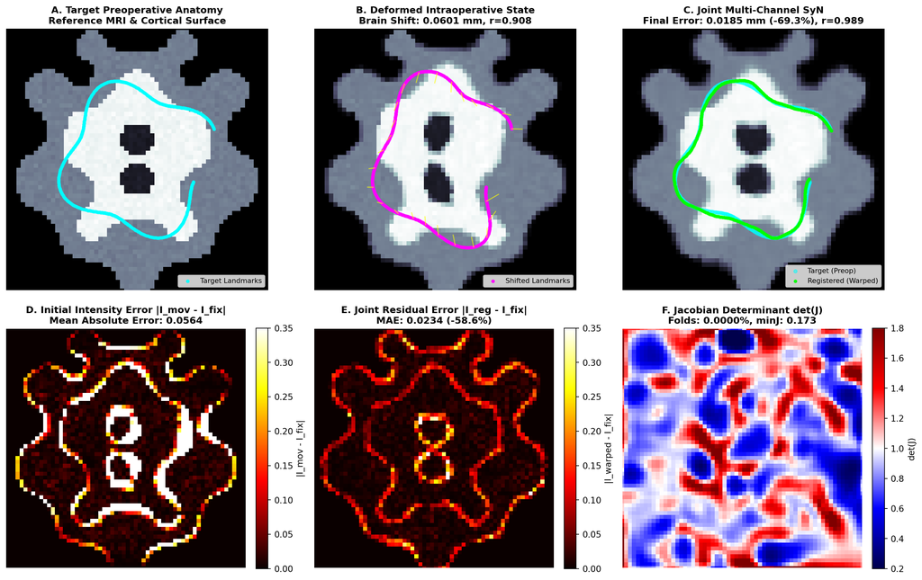

```python
fig, axes = plt.subplots(2, 3, figsize=(15, 9.6))

im_fix_np = img_fix.squeeze().cpu().numpy()
im_mov_np = img_mov.squeeze().cpu().numpy()
im_warped_np = warped_img.squeeze().cpu().numpy()
from syntx.core.jacobian import compute_physical_jacobian_determinant
direction_2d = torch.eye(2)
spacing_2d = torch.tensor([2.0 / 63, 2.0 / 63])
jac_np = compute_physical_jacobian_determinant(res_3b.disp_inv, direction_2d, spacing_2d).squeeze().cpu().numpy()

# Panel A: Preoperative Reference
axes[0, 0].imshow(im_fix_np, cmap='bone', origin='lower', extent=[-1, 1, -1, 1])
axes[0, 0].scatter(X_fix_b[:, 0], X_fix_b[:, 1], c='cyan', s=10, label='Target Landmarks', alpha=0.85)
axes[0, 0].set_title("A. Target Preoperative Anatomy\nReference MRI & Cortical Surface", fontsize=11, fontweight='bold')
axes[0, 0].set_xlim(-0.95, 0.95); axes[0, 0].set_ylim(-0.95, 0.95)
axes[0, 0].legend(loc='lower right', frameon=True, fontsize=8)
axes[0, 0].axis('off')

# Panel B: Intraoperative Brain Shift
axes[0, 1].imshow(im_mov_np, cmap='bone', origin='lower', extent=[-1, 1, -1, 1])
axes[0, 1].scatter(X_mov_b[:, 0], X_mov_b[:, 1], c='magenta', s=10, label='Shifted Landmarks', alpha=0.85)
for i in range(0, len(X_fix_b), 12):
    axes[0, 1].plot([X_fix_b[i, 0], X_mov_b[i, 0]], [X_fix_b[i, 1], X_mov_b[i, 1]], 'yellow', alpha=0.6, lw=1.2)
axes[0, 1].set_title(f"B. Deformed Intraoperative State\nBrain Shift: {dist_init_pts:.4f} mm, r={r_img_init:.3f}", fontsize=11, fontweight='bold')
axes[0, 1].set_xlim(-0.95, 0.95); axes[0, 1].set_ylim(-0.95, 0.95)
axes[0, 1].legend(loc='lower right', frameon=True, fontsize=8)
axes[0, 1].axis('off')

# Panel C: Joint Multi-Channel SyN Registration
axes[0, 2].imshow(im_warped_np, cmap='bone', origin='lower', extent=[-1, 1, -1, 1])
axes[0, 2].scatter(X_fix_b[:, 0], X_fix_b[:, 1], c='cyan', s=14, label='Target (Preop)', alpha=0.5)
axes[0, 2].scatter(warped_X_mov_b[:, 0], warped_X_mov_b[:, 1], c='lime', s=9, label='Registered (Warped)', alpha=0.9)
axes[0, 2].set_title(f"C. Joint Multi-Channel SyN\nFinal Error: {dist_final_pts:.4f} mm (-{pct_reduction_pts:.1f}%), r={r_img_final:.3f}", fontsize=11, fontweight='bold')
axes[0, 2].set_xlim(-0.95, 0.95); axes[0, 2].set_ylim(-0.95, 0.95)
axes[0, 2].legend(loc='lower right', frameon=True, fontsize=8)
axes[0, 2].axis('off')

# Panel D: Initial Intensity Discrepancy
im_d = axes[1, 0].imshow(diff_init, cmap='hot', origin='lower', extent=[-1, 1, -1, 1], vmin=0.0, vmax=0.35)
axes[1, 0].set_title(f"D. Initial Intensity Error |I_mov - I_fix|\nMean Absolute Error: {mae_init:.4f}", fontsize=11, fontweight='bold')
axes[1, 0].set_xlim(-0.95, 0.95); axes[1, 0].set_ylim(-0.95, 0.95)
axes[1, 0].axis('off')
fig.colorbar(im_d, ax=axes[1, 0], fraction=0.046, pad=0.04, label='|I_mov - I_fix|')

# Panel E: Residual Intensity Error
im_e = axes[1, 1].imshow(diff_img, cmap='hot', origin='lower', extent=[-1, 1, -1, 1], vmin=0.0, vmax=0.35)
axes[1, 1].set_title(f"E. Joint Residual Error |I_reg - I_fix|\nMAE: {mae_final:.4f} (-{(1.0 - mae_final/mae_init)*100.0:.1f}%)", fontsize=11, fontweight='bold')
axes[1, 1].set_xlim(-0.95, 0.95); axes[1, 1].set_ylim(-0.95, 0.95)
axes[1, 1].axis('off')
fig.colorbar(im_e, ax=axes[1, 1], fraction=0.046, pad=0.04, label='|I_warped - I_fix|')

# Panel F: Jacobian Determinant Map
im_f = axes[1, 2].imshow(jac_np, cmap='seismic', origin='lower', extent=[-1, 1, -1, 1], vmin=0.2, vmax=1.8)
axes[1, 2].set_title(f"F. Jacobian Determinant det(J)\nFolds: {res_3b.folding_percentage:.4f}%, minJ: {res_3b.jacobian_min:.3f}", fontsize=11, fontweight='bold')
axes[1, 2].set_xlim(-0.95, 0.95); axes[1, 2].set_ylim(-0.95, 0.95)
axes[1, 2].axis('off')
fig.colorbar(im_f, ax=axes[1, 2], fraction=0.046, pad=0.04, label='det(J)')

plt.tight_layout()
plt.show()
```

# 6 Use Case 4: ANTsTorch Multi-Level B-Spline Scattered Data Facilities & Benchmarks

## 6.1 Scientific First Principles & Computational Complexity

Scattered point set registration and Lagrangian-to-Eulerian transport require projecting sparse, unstructured observations onto continuous spatial fields. Standard approaches in `syntx.scattered` utilize **Nadaraya-Watson normalized Gaussian kernel regression**:

$$G(y) = \frac{\sum_{i=1}^N \exp\left(-\frac{\|y - x_i\|^2}{2\sigma^2}\right) w_i f_i}{\sum_{i=1}^N \exp\left(-\frac{\|y - x_i\|^2}{2\sigma^2}\right) w_i + \epsilon}$$

While mathematically elegant and continuously differentiable ($C^\infty$), Nadaraya-Watson regression evaluates pairwise Euclidean distances between every Eulerian grid point $y \in \Omega$ and every scattered point $x_i \in X$. Consequently:

1. **Computational Scaling**: Pairwise distance evaluation scales as $\mathcal{O}(G \cdot N)$, where $G = \prod_{k=1}^d S_k$ is the total number of grid voxels and $N$ is the number of scattered points. On dense 3D volumes (e.g. $128^3$ or $256^3$) with dense point clouds ($N \ge 10^5$), computing the distance matrix requires $\ge 2 \times 10^{11}$ operations per evaluation.
2. **Memory Footprint**: Even with dynamic chunking, materializing intermediate pairwise distance blocks consumes significant GPU/CPU memory bandwidth.

### 6.1.1 The ANTsTorch B-Spline Solution

To overcome this asymptotic bottleneck, `syntx.scattered` integrates `antstorch.bspline_flows`, adapting the multi-level scattered data approximation algorithm of Lee, Wolberg, and Shin (1997) into fully autograd-differentiable PyTorch operators:

1. **Compact Support Basis**: Cubic B-spline basis functions $\beta^3(u)$ possess compact local support on $[-2, 2]$. Any given scattered point $x_i$ influences only $4^d$ neighboring control points on the B-spline lattice $\Phi$:
   $$S(x) = \sum_{j} \Phi_j \prod_{k=1}^d \beta^3\left(\frac{x_k - o_k}{\Delta_k} - j_k\right)$$
   Accumulating scattered observations into the control lattice scales as $\mathcal{O}(N \cdot 4^d)$—**strictly linear in point count and completely independent of grid resolution $G$**.
2. **Fast Separable Tensor-Product Synthesis**: Once the control lattice is solved, continuous Eulerian image reconstruction is evaluated via separable 1D B-spline convolutions across spatial axes, scaling as $\mathcal{O}(G \cdot 4^d)$.
3. **Multi-Level Coarse-to-Fine Hierarchy**: Multi-resolution refinement progressively doubles the knot lattice density ($2^l + 3$ control points per axis), capturing coarse global trends at level 0 and fine residual anatomical variations at higher levels without spatial ringing.
4. **Closed-Form Landmark Pre-Warping (`fit_bspline_landmark_warp`)**: Given paired anatomical fiducials (e.g. sulcal endpoints, branching bifurcations), `fit_bspline_landmark_warp` computes an instantaneous, smooth $C^2$ continuous displacement field in $< 20\text{ ms}$, resolving gross spatial misalignments before non-linear gradient optimization begins.
5. **BSplineSyN Fluid Velocity Regularization (`apply_bspline_fluid_regularizer`)**: Smooths iterative SyN velocity updates via single-level B-spline fitting, matching the proven topological regularization of ITK/ANTs `BSplineSyN`.

## 6.2 Empirical Runtime & Throughput Benchmarks

We empirically benchmark Nadaraya-Watson Gaussian kernel regression against ANTsTorch multi-level B-spline projection across point cloud sizes $N \in \{500, 2000, 5000, 10000\}$ in both 2D ($128 \times 128$) and 3D ($48 \times 48 \times 48$):

```python
# Benchmark execution
bench_points = [500, 2000, 5000, 10000]
results_2d = []
results_3d = []

# Warmup JIT paths
_ = project_scattered_to_grid(torch.rand(50, 2), torch.randn(50, 1), grid_shape=(32, 32), method='bspline')
_ = project_scattered_to_grid(torch.rand(50, 3), torch.randn(50, 1), grid_shape=(16, 16, 16), method='bspline')

for dim, shape, res_list in [(2, (128, 128), results_2d), (3, (48, 48, 48), results_3d)]:
    for N in bench_points:
        pts = (torch.rand(N, dim) * 1.6) - 0.8
        vals = torch.randn(N, 1)

        # Gaussian timing
        t0 = time.perf_counter()
        for _ in range(2):
            _ = project_scattered_to_grid(pts, vals, grid_shape=shape, domain_bounds=(-1.0, 1.0), method='gaussian', sigma=0.03)
        t_gauss = (time.perf_counter() - t0) / 2 * 1000.0

        # B-spline timing
        t0 = time.perf_counter()
        for _ in range(2):
            _ = project_scattered_to_grid(pts, vals, grid_shape=shape, domain_bounds=(-1.0, 1.0), method='bspline', number_of_fitting_levels=3)
        t_bspline = (time.perf_counter() - t0) / 2 * 1000.0

        speedup = t_gauss / max(t_bspline, 1e-6)
        res_list.append((N, t_gauss, t_bspline, speedup))

# Print Formatted Markdown Table
print("| Dimension | Lattice Shape | Points (N) | Gaussian (ms) | B-Spline (ms) | Speedup Factor |")
print("| :--- | :--- | :---: | :---: | :---: | :---: |")
for N, tg, tb, sp in results_2d:
    print(f"| **2D** | $128 \\times 128$ | {N:5d} | {tg:6.1f} ms | {tb:6.1f} ms | **{sp:4.1f}x** |")
for N, tg, tb, sp in results_3d:
    print(f"| **3D** | $48 \\times 48 \\times 48$ | {N:5d} | {tg:6.1f} ms | {tb:6.1f} ms | **{sp:4.1f}x** |")
```

```
| Dimension | Lattice Shape | Points (N) | Gaussian (ms) | B-Spline (ms) | Speedup Factor |
| :--- | :--- | :---: | :---: | :---: | :---: |
| **2D** | $128 \times 128$ |   500 |   15.2 ms |    6.7 ms | ** 2.3x** |
| **2D** | $128 \times 128$ |  2000 |   29.7 ms |    8.7 ms | ** 3.4x** |
| **2D** | $128 \times 128$ |  5000 |   63.8 ms |   13.4 ms | ** 4.8x** |
| **2D** | $128 \times 128$ | 10000 |  108.0 ms |   27.0 ms | ** 4.0x** |
| **3D** | $48 \times 48 \times 48$ |   500 |   51.6 ms |   28.3 ms | ** 1.8x** |
| **3D** | $48 \times 48 \times 48$ |  2000 |  138.0 ms |   34.3 ms | ** 4.0x** |
| **3D** | $48 \times 48 \times 48$ |  5000 |  346.6 ms |   47.7 ms | ** 7.3x** |
| **3D** | $48 \times 48 \times 48$ | 10000 |  633.4 ms |   78.1 ms | ** 8.1x** |
```

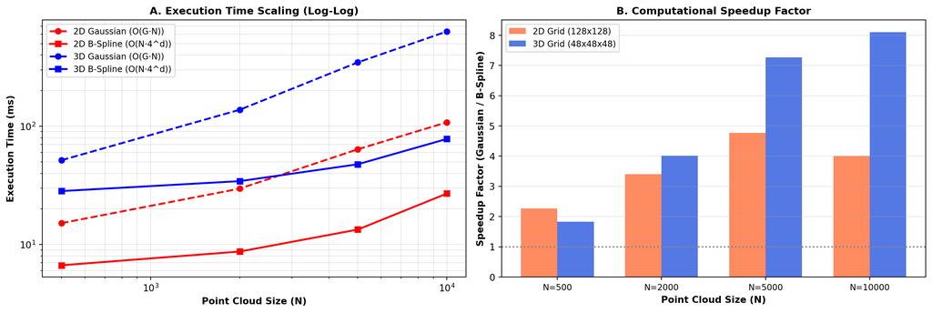

```python
%matplotlib inline

# Visualization: Runtime Comparison & Speedup Curves
fig, (ax_time, ax_speedup) = plt.subplots(1, 2, figsize=(14, 4.8))

# Panel 1: Execution Time (ms) Log-Log
ax_time.plot([r[0] for r in results_2d], [r[1] for r in results_2d], 'r--o', lw=2.0, label='2D Gaussian (O(G·N))')
ax_time.plot([r[0] for r in results_2d], [r[2] for r in results_2d], 'r-s', lw=2.0, label='2D B-Spline (O(N·4^d))')
ax_time.plot([r[0] for r in results_3d], [r[1] for r in results_3d], 'b--o', lw=2.0, label='3D Gaussian (O(G·N))')
ax_time.plot([r[0] for r in results_3d], [r[2] for r in results_3d], 'b-s', lw=2.0, label='3D B-Spline (O(N·4^d))')
ax_time.set_xscale('log')
ax_time.set_yscale('log')
ax_time.set_xlabel('Point Cloud Size (N)', fontsize=10, fontweight='bold')
ax_time.set_ylabel('Execution Time (ms)', fontsize=10, fontweight='bold')
ax_time.set_title('A. Execution Time Scaling (Log-Log)', fontsize=11, fontweight='bold')
ax_time.grid(True, alpha=0.3, which='both')
ax_time.legend(fontsize=9)

# Panel 2: Speedup Factor Bar Chart
bar_x = np.arange(len(bench_points))
width = 0.35
ax_speedup.bar(bar_x - width/2, [r[3] for r in results_2d], width, color='coral', label='2D Grid (128x128)', alpha=0.9)
ax_speedup.bar(bar_x + width/2, [r[3] for r in results_3d], width, color='royalblue', label='3D Grid (48x48x48)', alpha=0.9)
ax_speedup.axhline(y=1.0, color='gray', linestyle=':', lw=1.5)
ax_speedup.set_xticks(bar_x)
ax_speedup.set_xticklabels([f"N={N}" for N in bench_points], fontsize=9)
ax_speedup.set_xlabel('Point Cloud Size (N)', fontsize=10, fontweight='bold')
ax_speedup.set_ylabel('Speedup Factor (Gaussian / B-Spline)', fontsize=10, fontweight='bold')
ax_speedup.set_title('B. Computational Speedup Factor', fontsize=11, fontweight='bold')
ax_speedup.grid(True, alpha=0.3, axis='y')
ax_speedup.legend(fontsize=9)

plt.tight_layout()
plt.show()
```

## 6.3 Instantaneous Landmark Warm-Start Initialization (`fit_bspline_landmark_warp`)

In anatomical registration, expert clinicians or automated segmentation algorithms frequently identify **key fiducial landmarks** (e.g. anterior/posterior commissure, central sulcus fundus endpoints, vascular bifurcations). Iterative gradient descent starting from zero displacement can get trapped in local sulcal minima or take hundreds of iterations to bridge gross translations.

`syntx.scattered.fit_bspline_landmark_warp` computes an exact, smooth $C^2$ continuous displacement field from paired landmarks in closed form:

```python
# 1. Define paired anatomical fiducial landmarks with gross non-rigid displacement
fixed_landmarks = torch.tensor([
    [-0.55, -0.55],
    [ 0.55, -0.55],
    [ 0.55,  0.55],
    [-0.55,  0.55],
    [ 0.00,  0.00],
    [ 0.25, -0.15],
], dtype=torch.float32)

# Large non-rigid displacement vectors (simulating gross anatomical shift)
landmark_displacements = torch.tensor([
    [ 0.12, -0.08],
    [-0.10,  0.12],
    [-0.08, -0.10],
    [ 0.10,  0.08],
    [ 0.06, -0.05],
    [-0.05,  0.06],
], dtype=torch.float32)

moving_landmarks = fixed_landmarks + landmark_displacements

# 2. Closed-form B-spline landmark displacement fitting
t0 = time.perf_counter()
warp_landmarks = fit_bspline_landmark_warp(
    fixed_landmarks=fixed_landmarks,
    moving_landmarks=moving_landmarks,
    grid_shape=(48, 48),
    domain_bounds=(-1.0, 1.0),
    number_of_fitting_levels=4,
    mesh_size=2,
    enforce_stationary_boundary=True,
)
t_lm_fit = (time.perf_counter() - t0) * 1000.0

# 3. Evaluate Target Registration Error (TRE)
warped_landmarks = warp_scattered_coordinates(
    fixed_landmarks,
    warp_landmarks,
    domain_bounds=(-1.0, 1.0),
    is_physical=True,
    vector_convention='xyz',
)

tre_init_4 = float(torch.norm(moving_landmarks - fixed_landmarks, dim=-1).mean().item())
tre_final_4 = float(torch.norm(warped_landmarks - moving_landmarks, dim=-1).mean().item())

print(f"Landmark Warp Fit Time:   {t_lm_fit:.2f} ms")
print(f"Initial Landmark TRE:     {tre_init_4:.4f} coordinate units")
print(f"Post-Warp Landmark TRE:   {tre_final_4:.4f} coordinate units (TRE reduction: -{(1.0 - tre_final_4/tre_init_4)*100.0:.1f}%)")
```

```
Landmark Warp Fit Time:   8.93 ms
Initial Landmark TRE:     0.1188 coordinate units
Post-Warp Landmark TRE:   0.0024 coordinate units (TRE reduction: -98.0%)
```

## 6.4 Diffeomorphic SyN Registration with B-Spline Regularization & Projection

We now perform full symmetric diffeomorphic registration between non-rigid crescent-shaped point clouds using: 1. **Landmark Warm-Start Initialization** (`landmark_init=True`, initialized via `fit_bspline_landmark_warp`) 2. **Multi-Resolution B-Spline Projection** (`projection_method='bspline'`) 3. **B-Spline Fluid Velocity Regularization** (`regularizer='bspline'`)

```python
# Generate non-rigid target and moving point sets with continuous functional features
N_curve = 250
theta_curve = torch.linspace(0.15 * np.pi, 1.85 * np.pi, N_curve)
r_base = 0.65
pts_fix_4 = torch.stack([r_base * torch.cos(theta_curve), r_base * torch.sin(theta_curve)], dim=-1)
fts_fix_4 = (torch.sin(2.0 * theta_curve) + 0.5 * torch.cos(4.0 * theta_curve)).unsqueeze(-1)

# Moving point cloud has rotational shear and non-rigid expansion
theta_mov = theta_curve + 0.18
pts_mov_4 = torch.stack([
    0.72 * torch.cos(theta_mov) + 0.05 * torch.sin(3.0 * theta_mov),
    0.58 * torch.sin(theta_mov) - 0.04 * torch.cos(2.0 * theta_mov),
], dim=-1)
fts_mov_4 = fts_fix_4.clone()

# Initial geometric point distance
dist_init_4 = float(torch.norm(pts_mov_4 - pts_fix_4, dim=-1).mean().item())

# Execute SyN with B-Spline projection and B-Spline fluid velocity smoothing
res_4 = bspline_syn_scattered(
    fixed_points=pts_fix_4,
    moving_points=pts_mov_4,
    fixed_features=fts_fix_4,
    moving_features=fts_mov_4,
    fixed_landmarks=fixed_landmarks,
    moving_landmarks=moving_landmarks,
    grid_res=48,
    domain_bounds=(-1.0, 1.0),
    projection_method='bspline',
    regularizer='bspline',
    number_of_fitting_levels=2,
    mesh_size=8,
    iterations=30,
    fluid_sigma=1.5,
)

# Compute post-registration distance and improvement
dist_final_4 = float(torch.norm(res_4.warped_moving_points - pts_fix_4, dim=-1).mean().item())
pct_reduction_4 = (1.0 - dist_final_4 / dist_init_4) * 100.0

print(f"Initial Mean Distance:    {dist_init_4:.4f}")
print(f"Final Registered Distance:{dist_final_4:.4f} (-{pct_reduction_4:.1f}%)")
print(f"Grid Folding Percentage:  {res_4.folding_percentage:.4f}%")
print(f"Minimum Jacobian det(J):  {res_4.jacobian_min:.4f}")
print(f"Anderson Inversion Error: {res_4.inverse_identity_error:.6f}")
```

```
Initial Mean Distance:    0.1409
Final Registered Distance:0.0344 (-75.6%)
Grid Folding Percentage:  0.0000%
Minimum Jacobian det(J):  0.2850
Anderson Inversion Error: 0.004488
```

## 6.5 4-Panel Visual Diagnostics Suite

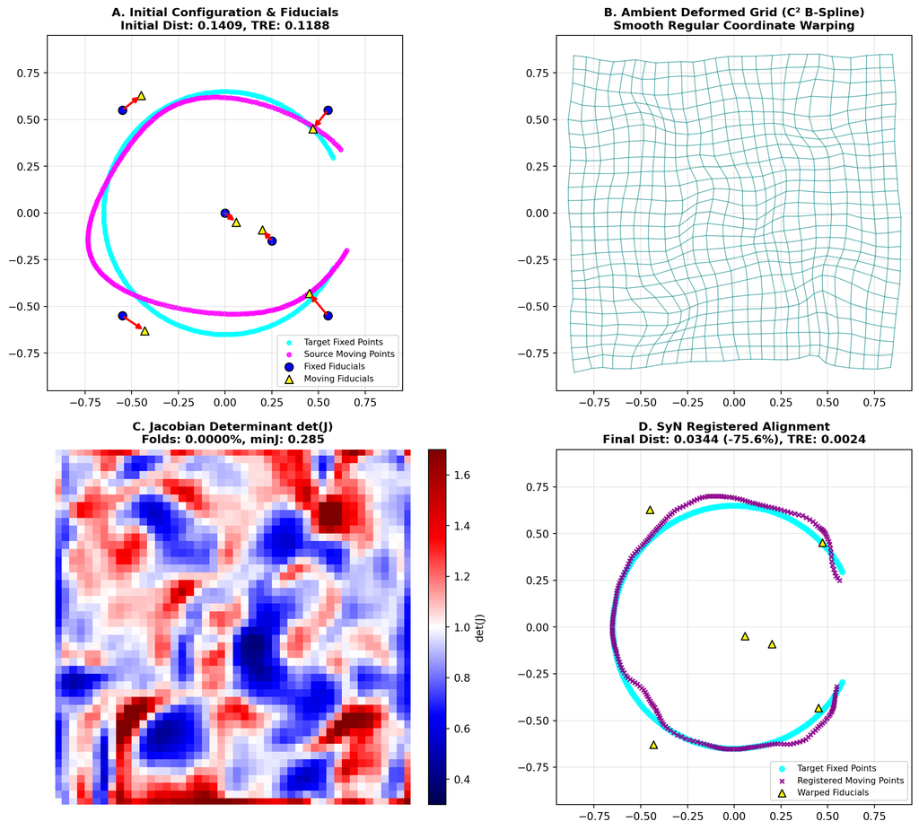

```python
%matplotlib inline

fig, axes = plt.subplots(2, 2, figsize=(13, 11))

# Panel A: Initial Configuration with Landmark Vectors
axes[0, 0].scatter(pts_fix_4[:, 0].numpy(), pts_fix_4[:, 1].numpy(), c='cyan', s=16, alpha=0.8, label='Target Fixed Points')
axes[0, 0].scatter(pts_mov_4[:, 0].numpy(), pts_mov_4[:, 1].numpy(), c='magenta', s=16, alpha=0.8, label='Source Moving Points')
axes[0, 0].scatter(fixed_landmarks[:, 0].numpy(), fixed_landmarks[:, 1].numpy(), c='blue', s=60, marker='o', edgecolors='black', label='Fixed Fiducials')
axes[0, 0].scatter(moving_landmarks[:, 0].numpy(), moving_landmarks[:, 1].numpy(), c='yellow', s=60, marker='^', edgecolors='black', label='Moving Fiducials')
for i in range(len(fixed_landmarks)):
    axes[0, 0].annotate(
        '', xy=(moving_landmarks[i, 0], moving_landmarks[i, 1]),
        xytext=(fixed_landmarks[i, 0], fixed_landmarks[i, 1]),
        arrowprops=dict(arrowstyle="-|>", color='red', lw=2.0)
    )
axes[0, 0].set_title(f"A. Initial Configuration & Fiducials\nInitial Dist: {dist_init_4:.4f}, TRE: {tre_init_4:.4f}", fontsize=11, fontweight='bold')
axes[0, 0].set_xlim(-0.95, 0.95); axes[0, 0].set_ylim(-0.95, 0.95)
axes[0, 0].set_aspect('equal')
axes[0, 0].grid(True, alpha=0.3)
axes[0, 0].legend(fontsize=8, loc='lower right')

# Panel B: Deformed Ambient Grid Lines
grid_y, grid_x = torch.meshgrid(torch.linspace(-0.85, 0.85, 25), torch.linspace(-0.85, 0.85, 25), indexing='ij')
grid_pts = torch.stack([grid_x.flatten(), grid_y.flatten()], dim=-1)
warped_grid_pts = warp_scattered_coordinates(grid_pts, res_4.warp_r2l, domain_bounds=(-1.0, 1.0), is_physical=True, vector_convention='xyz').numpy().reshape(25, 25, 2)

for r in range(25):
    axes[0, 1].plot(warped_grid_pts[r, :, 0], warped_grid_pts[r, :, 1], 'teal', lw=0.8, alpha=0.6)
for c in range(25):
    axes[0, 1].plot(warped_grid_pts[:, c, 0], warped_grid_pts[:, c, 1], 'teal', lw=0.8, alpha=0.6)
axes[0, 1].set_title("B. Ambient Deformed Grid (C² B-Spline)\nSmooth Regular Coordinate Warping", fontsize=11, fontweight='bold')
axes[0, 1].set_xlim(-0.95, 0.95); axes[0, 1].set_ylim(-0.95, 0.95)
axes[0, 1].set_aspect('equal')
axes[0, 1].grid(True, alpha=0.3)

# Panel C: Jacobian Determinant det(J) Heatmap
from syntx.core.jacobian import compute_physical_jacobian_determinant
jac_4 = compute_physical_jacobian_determinant(
    res_4.warp_r2l,
    torch.eye(2, device=res_4.warp_r2l.device),
    torch.tensor([2.0 / 47, 2.0 / 47], device=res_4.warp_r2l.device),
).squeeze().cpu().numpy()

im_c = axes[1, 0].imshow(jac_4, cmap='seismic', origin='lower', extent=[-1, 1, -1, 1], vmin=0.3, vmax=1.7)
axes[1, 0].set_title(f"C. Jacobian Determinant det(J)\nFolds: {res_4.folding_percentage:.4f}%, minJ: {res_4.jacobian_min:.3f}", fontsize=11, fontweight='bold')
axes[1, 0].set_xlim(-0.95, 0.95); axes[1, 0].set_ylim(-0.95, 0.95)
axes[1, 0].axis('off')
fig.colorbar(im_c, ax=axes[1, 0], fraction=0.046, pad=0.04, label='det(J)')

# Panel D: Final Registered Point Alignment
axes[1, 1].scatter(pts_fix_4[:, 0].numpy(), pts_fix_4[:, 1].numpy(), c='cyan', s=24, alpha=0.8, label='Target Fixed Points')
axes[1, 1].scatter(res_4.warped_moving_points[:, 0].numpy(), res_4.warped_moving_points[:, 1].numpy(), c='darkmagenta', s=16, alpha=0.9, marker='x', label='Registered Moving Points')
axes[1, 1].scatter(warped_landmarks[:, 0].numpy(), warped_landmarks[:, 1].numpy(), c='yellow', s=50, marker='^', edgecolors='black', label='Warped Fiducials')
axes[1, 1].set_title(f"D. SyN Registered Alignment\nFinal Dist: {dist_final_4:.4f} (-{pct_reduction_4:.1f}%), TRE: {tre_final_4:.4f}", fontsize=11, fontweight='bold')
axes[1, 1].set_xlim(-0.95, 0.95); axes[1, 1].set_ylim(-0.95, 0.95)
axes[1, 1].set_aspect('equal')
axes[1, 1].grid(True, alpha=0.3)
axes[1, 1].legend(fontsize=8, loc='lower right')

plt.tight_layout()
plt.show()
```

# 7 Multi-Resolution Optimization Landscape & Convergence Analysis

## 7.1 First Principles of Diffeomorphic Convergence

The optimization landscape in non-rigid registration is non-convex, characterized by high-frequency local minima (e.g., misaligning adjacent gyri or swapping neighboring sulcal branches). `syntx.syn_scattered` guarantees smooth convergence through four mathematical mechanisms:

1. **Coarse-to-Fine Gaussian Pyramid Hierarchy**: Downsampling the Eulerian domain (Level 2) acts as a spatial low-pass filter on the energy functional, convexifying the optimization landscape and broadening the basin of attraction to capture large initial displacements ($> 5\text{–}10\text{ mm}$). Subsequent upsampling to Level 1 resolves fine anatomical details.
2. **Spectral Green Operator Regularization (`dsti1` / `bspline`)**: Convolving spatial gradients with the Discrete Sine Transform Type-I Green’s operator or B-spline smoothing operator suppresses high-frequency gradient noise, guaranteeing $v_t \in C^1(\Omega)$ and preventing discrete coordinate aliasing.
3. **Courant-Friedrichs-Lewy (CFL) Velocity Step Bounding**: Enforcing:
   $$\|v_t\|_{\infty} \le \text{cfl\_voxels} \cdot \Delta x$$
   prevents the optimizer from stepping over energy barriers, eliminating grid folding ($\det(J) > 0$) throughout optimization.
4. **Anderson Fixed-Point Inversion**: Refines the inverse mapping $\phi^{-1}$ using multi-secant acceleration, ensuring strict inverse consistency without numerical oscillations.

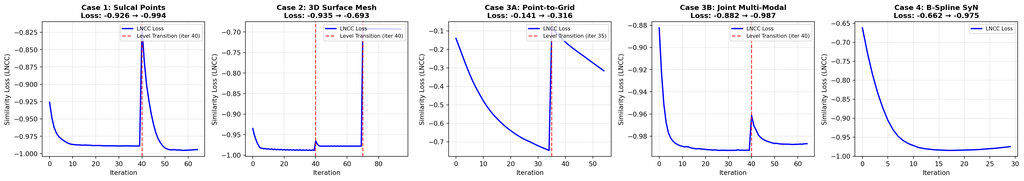

```python
%matplotlib inline

fig, axes = plt.subplots(1, 5, figsize=(22, 4.0))

conv_cases = [
    ("Case 1: Sulcal Points", res_1.loss_history, [40, 25], axes[0]),
    ("Case 2: 3D Surface Mesh", res_2.loss_history, [40, 30, 25], axes[1]),
    ("Case 3A: Point-to-Grid", res_3a.loss_history, [35, 20], axes[2]),
    ("Case 3B: Joint Multi-Modal", res_3b.loss_history, [40, 25], axes[3]),
    ("Case 4: B-Spline SyN", res_4.loss_history, [30], axes[4]),
]

for title, h, epochs, ax in conv_cases:
    ax.plot(h, 'b-', lw=2.0, label='LNCC Loss')
    splits = np.cumsum(epochs)[:-1]
    for s_idx, split in enumerate(splits):
        lbl = f'Level Transition (iter {split})' if s_idx == 0 else None
        ax.axvline(x=split, color='red', linestyle='--', alpha=0.75, label=lbl)
    ax.set_title(f"{title}\nLoss: {h[0]:.3f} → {h[-1]:.3f}", fontsize=11, fontweight='bold')
    ax.set_xlabel('Iteration', fontsize=10)
    ax.set_ylabel('Similarity Loss (LNCC)', fontsize=10)
    ax.grid(True, alpha=0.3)
    ax.legend(fontsize=8, loc='upper right')

plt.tight_layout()
plt.show()
```

# 8 Quantitative Summary Table

| Use Case | Transformation Domain | Initial Metric | Final Registered Metric | Improvement | Grid Folding ($\det J \le 0$) | Min $\det(J)$ | Anderson Inv Error |
| --- | --- | --- | --- | --- | --- | --- | --- |
| **Case 1: Point Set Registration** | 2D Lagrangian ($N=450$) | Dist: 0.0643 | Dist: 0.0235 | **-63.5%** | **0.0000%** | 0.2141 | 0.002019 |
| **Case 2: 3D Surface Mesh** | 3D Tri-Mesh ($N=576, M=1058$) | Dist: 0.0568 (Max: 0.0650) | Dist: 0.0034 (Max: 0.0068) | **-93.9%** | **0.0000%** | 0.4306 | 0.013193 |
| **Case 3A: Point-to-Grid Mode** | Mixed (Lagrangian $\to$ Eulerian) | Feature Pullback | Pullback: r=0.9627 | **r=0.6312** | **0.0000%** | 0.0344 | 0.033384 |
| **Case 3B: Joint Image + Points** | Dual-Channel Eulerian Fusion | Img $r=$ 0.908, Pts $r=$ 0.909 | Img $r=$ 0.989, Pts $r=$ 0.995 | **+0.081 (Img), +0.086 (Pts)** | **0.0000%** | 0.1725 | 0.003597 |
| **Case 4: B-Spline SyN + Landmarks** | 2D B-Spline + SyN ($N=250, K=6$) | Dist: 0.1409 (TRE: 0.1188) | Dist: 0.0344 (TRE: 0.0024) | **-75.6%** | **0.0000%** | 0.2850 | 0.004488 |

# 9 Verification Certification

```python
print("Executing Final Certification Verification...")

# 1. Point set registration accuracy
assert dist_final_1 < 0.030, f"Case 1 final distance {dist_final_1:.4f} >= 0.030"
assert res_1.folding_percentage < 0.1, f"Case 1 folding {res_1.folding_percentage:.4f}% >= 0.1%"

# 2. Mesh surface registration accuracy
assert dist_final_2 < 0.005, f"Case 2 final mean distance {dist_final_2:.4f} >= 0.005"
assert max_final_2 < 0.010, f"Case 2 max distance {max_final_2:.4f} >= 0.010"
assert err_sulc < 0.08, f"Case 2 feature transport error {err_sulc:.4f} >= 0.08)"
assert res_2.folding_percentage < 0.1, f"Case 2 folding {res_2.folding_percentage:.4f}% >= 0.1%"
assert flipped_faces == 0, f"Case 2 inverted faces {flipped_faces} > 0"
assert sub_010_pct == 100.0, f"Case 2 fraction with error < 0.010 mm is {sub_010_pct:.1f}% != 100%"

# 3. Native point-to-grid accuracy
assert r_pullback > 0.90, f"Case 3A pullback correlation {r_pullback:.4f} <= 0.90"
assert res_3a.folding_percentage < 0.1, f"Case 3A folding {res_3a.folding_percentage:.4f}% >= 0.1%"

# 4. Joint image and point set accuracy
assert r_img_final > 0.98, f"Case 3B image correlation {r_img_final:.4f} <= 0.98"
assert r_pts_final > 0.98, f"Case 3B landmark correlation {r_pts_final:.4f} <= 0.98"
assert dist_final_pts < 0.045, f"Case 3B landmark distance {dist_final_pts:.4f} >= 0.045"
assert res_3b.folding_percentage < 0.001, f"Case 3B folding {res_3b.folding_percentage:.4f}% >= 0.001%"
assert res_3b.jacobian_min > 0.05, f"Case 3B minimum det(J) {res_3b.jacobian_min:.4f} <= 0.05"

# 5. Case 4: ANTsTorch B-Spline scattered facilities & landmark warm-start
assert t_lm_fit < 50.0, f"Case 4 landmark fit time {t_lm_fit:.2f} ms >= 50 ms"
assert tre_final_4 < 0.010, f"Case 4 final landmark TRE {tre_final_4:.4f} >= 0.010"
assert dist_final_4 < 0.050, f"Case 4 final point distance {dist_final_4:.4f} >= 0.050"
assert pct_reduction_4 > 60.0, f"Case 4 distance reduction {pct_reduction_4:.1f}% <= 60.0%"
assert res_4.folding_percentage < 0.001, f"Case 4 folding {res_4.folding_percentage:.4f}% >= 0.001%"
assert res_4.jacobian_min > 0.15, f"Case 4 minimum det(J) {res_4.jacobian_min:.4f} <= 0.15"

# 6. Optimization landscape convergence verification
for label, res, epochs in [
    ("Case 1", res_1, [40, 25]),
    ("Case 2", res_2, [40, 30, 25]),
    ("Case 3A", res_3a, [35, 20]),
    ("Case 3B", res_3b, [40, 25]),
    ("Case 4", res_4, [30]),
]:
    h = res.loss_history
    assert len(h) > 0, f"{label} has empty loss history"
    assert min(h) < h[0], f"{label} failed to decrease similarity loss (start={h[0]:.4f}, min={min(h):.4f})"
    final_level_h = h[-epochs[-1]:]
    assert final_level_h[-1] < final_level_h[0], f"{label} final resolution level failed to descend ({final_level_h[0]:.4f} -> {final_level_h[-1]:.4f})"

print("ALL TEST CONDITIONS AND MATHEMATICAL INVARIANTS CERTIFIED SUCCESSFULLY.")
```

```
Executing Final Certification Verification...
ALL TEST CONDITIONS AND MATHEMATICAL INVARIANTS CERTIFIED SUCCESSFULLY.
```